# Multi Omic Data explioration

Edmond Géraud Aguilar

3 de mayo, 2021

```r
> library(GEOquery)
> library(ggplot2)
> library(limma)
> library(DESeq2)
> library(Rsubread)
> library(data.table)
> library(edgeR)
> library(ggrepel)
> library(sva)
```

# 1 Description of original publication of data-set to be applied

## 1.1 Setup environment

```r
> dir.create("./results")
```

## 1.2 Metadata analysis

```r
> metadata.file <- "./data/rnaseqData/metadata.csv"
> metadata.raw <- read.csv(file = metadata.file, header = T, sep = ",",
+     dec = ".")
> w <- unlist(apply(metadata.raw, 2, function(x) which(is.na(x))))
> metadata <- metadata.raw[-w, ]
> # kableExtra::kable(metadata)
> kableExtra::kable(metadata)
```

|  | Sample.ID | Study.Group | Gender | Age.at.death | PMI..hr. | Braak | Cerad | RIN..RNA. | neuron…. | Cause.of.Death |
| --- | --- | --- | --- | --- | --- | --- | --- | --- | --- | --- |
| 2 | 2 | Young | Male | 42 | 16.0 | 0 | 0 | 8.8 | 21.8 | liver failure |
| 3 | 3 | Young | Male | 60 | 18.0 | 0 | 0 | 7.8 | 33.3 | complications following surgery for esophageal cancer/COPD/sepsis |
| 4 | 4 | Young | Male | 57 | 14.0 | 0 | 0 | 8.3 | 35.8 | kidney and liver failure following surgery for aortic aneurism |
| 5 | 5 | Young | Male | 42 | 16.0 | 0 | 0 | 7.2 | 47.1 | liver failure |
| 6 | 6 | Young | Male | 59 | 17.0 | 0 | 0 | 8.4 | 26.2 | complications following surgery for gall bladder removal |
| 7 | 7 | Young | Male | 55 | 11.5 | 0 | 0 | 8.6 | 41.3 | sepsis/ history of diabetes and cardiac disease |
| 8 | 8 | Young | Male | 52 | 12.0 | 0 | 0 | 8.1 | 23.3 | complications following surgery for aortic aneurism |
| 9 | 9 | Young | Female | 46 | 12.0 | 0 | 0 | 7.3 | 28.0 | liver failure |
| 10 | 10 | Old | Male | 73 | 17.0 | I/II | 0 | 8.4 | 22.9 | cancer/pulmonary thrombosis |
| 11 | 11 | Old | Male | 63 | 8.5 | 0 | 0 | 7.0 | 24.7 | leukemia/pneumonia |
| 12 | 12 | Old | Male | 62 | 16.0 | 0 | 0 | 7.9 | 24.9 | gastric adenocarcinoma |
| 13 | 13 | Old | Male | 68 | 21.0 | I/II | 0 | 6.7 | 23.9 | septic shock/pneumonia |
| 14 | 14 | Old | Male | 70 | 8.0 | I/II | 0 | 5.6 | 20.6 | coronary artery disease/COPD/ died of bypass surgery complications |
| 15 | 15 | Old | Male | 77 | 4.0 | I/II | 0 | 6.3 | 8.6 | cardiac arrest |
| 16 | 16 | Old | Male | 61 | 6.0 | 0 | 0 | 8.0 | 29.8 | liver cancer |
| 17 | 17 | Old | Male | 68 | 14.0 | 0 | 0 | 8.2 | 24.1 | cancer of stomach and esophagus |
| 18 | 18 | Old | Male | 72 | 17.0 | 0 | 0 | 7.1 | 14.1 | heart failure |
| 19 | 19 | Old | Female | 68 | 15.0 | I/II | 0 | 6.5 | 16.4 | septic shock |
| 20 | 20 | AD | Male | 64 | 16.5 | V/VI | C | 7.8 | 14.0 | complications from AD |
| 21 | 21 | AD | Male | 63 | 16.0 | V/VI | C | 7.0 | 15.6 | complications from AD |
| 22 | 22 | AD | Male | 71 | 5.0 | V/VI | C | 7.7 | 32.6 | complications from AD |
| 23 | 23 | AD | Male | 74 | 18.0 | V/VI | C | 6.3 | 23.8 | complications from AD |
| 24 | 24 | AD | Male | 78 | 11.0 | V/VI | C | 5.4 | 9.9 | complications from AD |
| 25 | 25 | AD | Male | 61 | 21.0 | V/VI | C | 5.3 | 25.7 | complications from AD |
| 26 | 26 | AD | Male | 65 | 17.0 | V/VI | C | 6.9 | 24.9 | complications from AD |
| 27 | 27 | AD | Female | 70 | 19.0 | V/VI | C | 4.3 | 13.7 | complications from AD |
| 28 | 28 | AD | Male | 79 | 12.0 | V/VI | C | 6.9 | 10.3 | complications from AD |
| 29 | 29 | AD | Male | 64 | 16.0 | V/VI | C | 6.2 | 12.4 | complications from AD |
| 30 | 30 | AD | Male | 64 | 5.0 | V/VI | C | 7.7 | 14.7 | complications from AD |
| 31 | 31 | AD | Male | 67 | 10.0 | V/VI | C | 6.4 | 22.4 | complications from AD |

### 1.2.1 Descriptive analysis

We have gender, age at death, post mortem hours, Braak and Cerad soroes, integrity numbers for RNA, and percentage of neurons (they don’t specify what it is)

Let’s see first classify cause of death by complications of AD and others, and also, convert into factors, group, gender, Cerad, Braak into factors.

```r
> colnames(metadata) <- c("ID", "Group", "Gender", "AgeDeath",
+     "PMI", "Braak", "Cerad", "RIN_RNA", "neuron", "CauseDeath")  ## column names chaged for easy manipulation
>
> ## Classifiying cause of death
> w <- grep("AD", metadata$CauseDeath)
> metadata$CauseDeath[w] <- "ADcomp"
> metadata$CauseDeath[-w] <- "Other"
> ## characters to factos
> for (j in 1:ncol(metadata)) {
+
+     if (class(metadata[, j]) == "character") {
+         metadata[, j] <- as.factor(metadata[, j])
+     }
+
+ }
```

Let’s se how the data is finally

```r
> metadata.copy <- metadata[, -1]  # let's remove the index
> str(metadata.copy)
```

```
'data.frame':   30 obs. of  9 variables:
 $ Group     : Factor w/ 3 levels "AD","Old","Young": 3 3 3 3 3 3 3 3 2 2 ...
 $ Gender    : Factor w/ 2 levels "Female","Male": 2 2 2 2 2 2 2 1 2 2 ...
 $ AgeDeath  : int  42 60 57 42 59 55 52 46 73 63 ...
 $ PMI       : num  16 18 14 16 17 11.5 12 12 17 8.5 ...
 $ Braak     : Factor w/ 3 levels "0","I/II","V/VI": 1 1 1 1 1 1 1 1 2 1 ...
 $ Cerad     : Factor w/ 2 levels "0","C": 1 1 1 1 1 1 1 1 1 1 ...
 $ RIN_RNA   : num  8.8 7.8 8.3 7.2 8.4 8.6 8.1 7.3 8.4 7 ...
 $ neuron    : num  21.8 33.3 35.8 47.1 26.2 41.3 23.3 28 22.9 24.7 ...
 $ CauseDeath: Factor w/ 2 levels "ADcomp","Other": 2 2 2 2 2 2 2 2 2 2 ...
```

First of all let’s observe the min, max, the quartiles, and the mean, for numerical variables, and the categorical variables, his levels for each group.

```r
> sumarizacion <- function(datos, grupo) {
+
+     datos.grupo <- datos[datos$Group == grupo, ]
+     datos.grupo$Group <- droplevels(datos.grupo$Group)
+     s <- summary(datos.grupo)
+     s[is.na(s)] <- ""
+     lista <- list(summary = s, data = datos.grupo)
+     return(lista)
+
+
+ }
> young <- sumarizacion(metadata.copy, "Young")
> kableExtra::kable(young$summary)
```

|  | Group | Gender | AgeDeath | PMI | Braak | Cerad | RIN_RNA | neuron | CauseDeath |
| --- | --- | --- | --- | --- | --- | --- | --- | --- | --- |
|  | Young:8 | Female:1 | Min. :42.00 | Min. :11.50 | 0 :8 | 0:8 | Min. :7.200 | Min. :21.80 | ADcomp:0 |
|  |  | Male :7 | 1st Qu.:45.00 | 1st Qu.:12.00 | I/II:0 | C:0 | 1st Qu.:7.675 | 1st Qu.:25.48 | Other :8 |
|  |  |  | Median :53.50 | Median :15.00 | V/VI:0 |  | Median :8.200 | Median :30.65 |  |
|  |  |  | Mean :51.62 | Mean :14.56 |  |  | Mean :8.062 | Mean :32.10 |  |
|  |  |  | 3rd Qu.:57.50 | 3rd Qu.:16.25 |  |  | 3rd Qu.:8.450 | 3rd Qu.:37.17 |  |
|  |  |  | Max. :60.00 | Max. :18.00 |  |  | Max. :8.800 | Max. :47.10 |  |

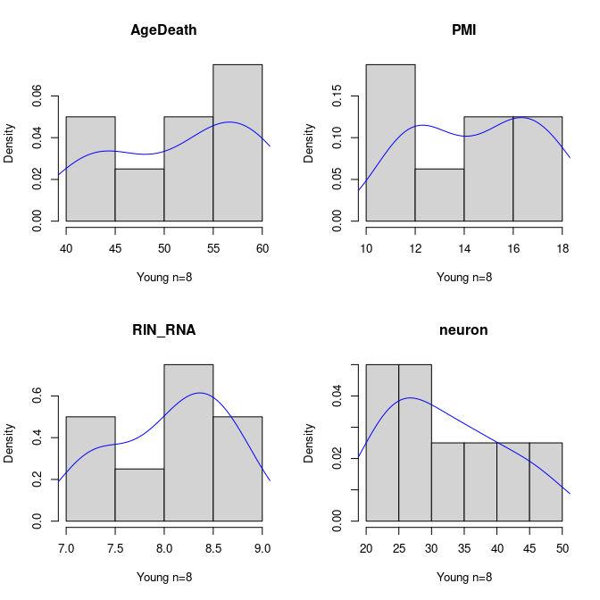

```r
> par(mfrow = c(2, 2))
> for (i in 1:ncol(young$data)) {
+
+     if (class(young$data[, i]) != "factor") {
+
+         hist(young$data[, i], main = colnames(young$data)[i],
+             freq = FALSE, xlab = "Young n=8")
+         lines(density(young$data[, i]), col = "blue")
+
+     }
+
+ }
```

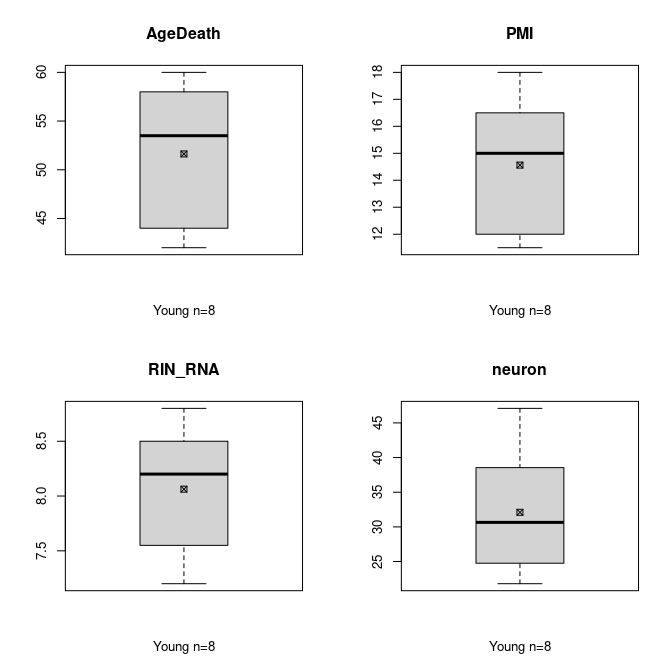

```r
> par(mfrow = c(2, 2))
> for (i in 1:ncol(young$data)) {
+
+     if (class(young$data[, i]) != "factor") {
+
+         boxplot(young$data[, i], main = colnames(young$data)[i],
+             freq = FALSE, xlab = "Young n=8")
+         points(mean(young$data[, i]), pch = 7)
+
+     }
+
+ }
```

```r
> old <- sumarizacion(metadata.copy, "Old")
> kableExtra::kable(old$summary)
```

|  | Group | Gender | AgeDeath | PMI | Braak | Cerad | RIN_RNA | neuron | CauseDeath |
| --- | --- | --- | --- | --- | --- | --- | --- | --- | --- |
|  | Old:10 | Female:1 | Min. :61.00 | Min. : 4.000 | 0 :5 | 0:10 | Min. :5.600 | Min. : 8.60 | ADcomp: 0 |
|  |  | Male :9 | 1st Qu.:64.25 | 1st Qu.: 8.125 | I/II:5 | C: 0 | 1st Qu.:6.550 | 1st Qu.:17.45 | Other :10 |
|  |  |  | Median :68.00 | Median :14.500 | V/VI:0 |  | Median :7.050 | Median :23.40 |  |
|  |  |  | Mean :68.20 | Mean :12.650 |  |  | Mean :7.170 | Mean :21.00 |  |
|  |  |  | 3rd Qu.:71.50 | 3rd Qu.:16.750 |  |  | 3rd Qu.:7.975 | 3rd Qu.:24.55 |  |
|  |  |  | Max. :77.00 | Max. :21.000 |  |  | Max. :8.400 | Max. :29.80 |  |

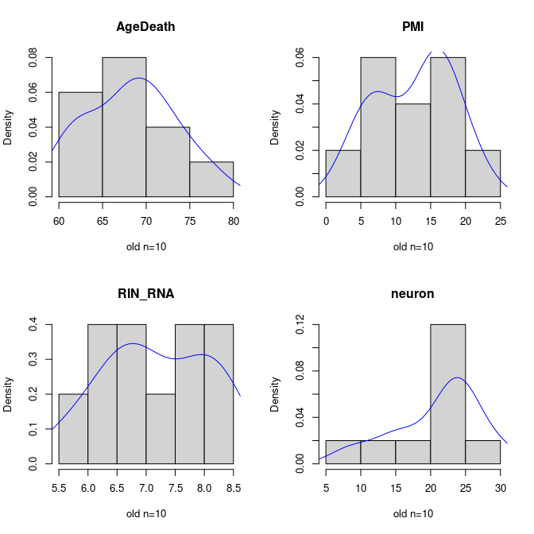

```r
> par(mfrow = c(2, 2))
> for (i in 1:ncol(old$data)) {
+
+     if (class(old$data[, i]) != "factor") {
+
+         hist(old$data[, i], main = colnames(old$data)[i], freq = FALSE,
+             xlab = "old n=10")
+         lines(density(old$data[, i]), col = "blue")
+
+     }
+
+ }
```

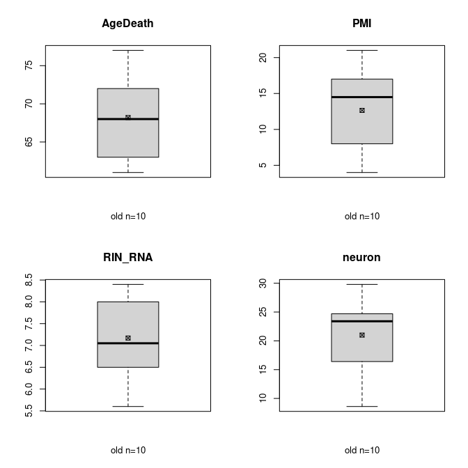

```r
> par(mfrow = c(2, 2))
> for (i in 1:ncol(old$data)) {
+
+     if (class(old$data[, i]) != "factor") {
+
+         boxplot(old$data[, i], main = colnames(old$data)[i],
+             freq = FALSE, xlab = "old n=10")
+         points(mean(old$data[, i]), pch = 7)
+
+     }
+
+ }
```

```r
> ad <- sumarizacion(metadata.copy, "AD")
> kableExtra::kable(ad$summary)
```

|  | Group | Gender | AgeDeath | PMI | Braak | Cerad | RIN_RNA | neuron | CauseDeath |
| --- | --- | --- | --- | --- | --- | --- | --- | --- | --- |
|  | AD:12 | Female: 1 | Min. :61.00 | Min. : 5.00 | 0 : 0 | 0: 0 | Min. :4.300 | Min. : 9.90 | ADcomp:12 |
|  |  | Male :11 | 1st Qu.:64.00 | 1st Qu.:10.75 | I/II: 0 | C:12 | 1st Qu.:6.000 | 1st Qu.:13.38 | Other : 0 |
|  |  |  | Median :66.00 | Median :16.00 | V/VI:12 |  | Median :6.650 | Median :15.15 |  |
|  |  |  | Mean :68.33 | Mean :13.88 |  |  | Mean :6.492 | Mean :18.33 |  |
|  |  |  | 3rd Qu.:71.75 | 3rd Qu.:17.25 |  |  | 3rd Qu.:7.175 | 3rd Qu.:24.07 |  |
|  |  |  | Max. :79.00 | Max. :21.00 |  |  | Max. :7.800 | Max. :32.60 |  |

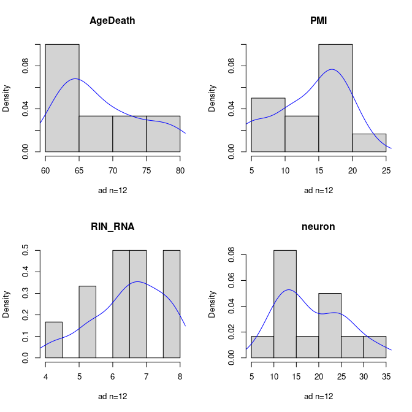

```r
> par(mfrow = c(2, 2))
> for (i in 1:ncol(ad$data)) {
+
+     if (class(ad$data[, i]) != "factor") {
+
+         hist(ad$data[, i], main = colnames(ad$data)[i], freq = FALSE,
+             xlab = "ad n=12")
+         lines(density(ad$data[, i]), col = "blue")
+
+     }
+
+ }
```

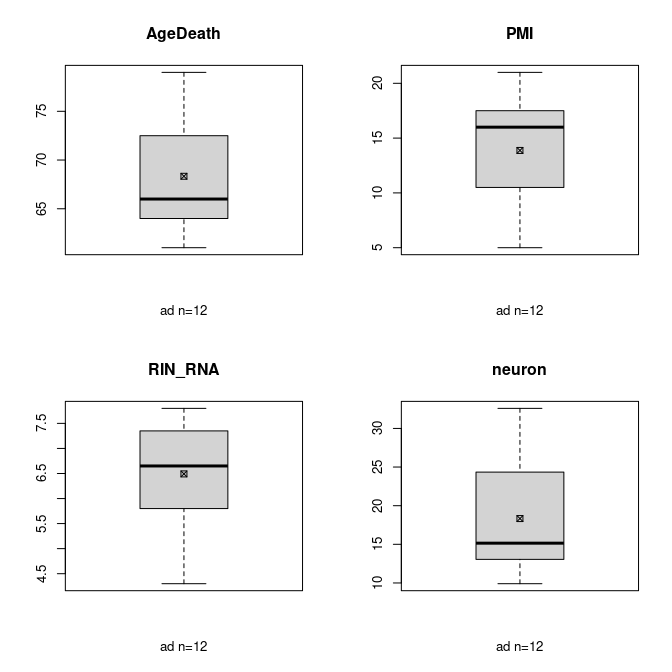

```r
> par(mfrow = c(2, 2))
> for (i in 1:ncol(ad$data)) {
+
+     if (class(ad$data[, i]) != "factor") {
+
+         boxplot(ad$data[, i], main = colnames(ad$data)[i], freq = FALSE,
+             xlab = "ad n=12")
+         points(mean(ad$data[, i]), pch = 7)
+
+     }
+
+ }
```

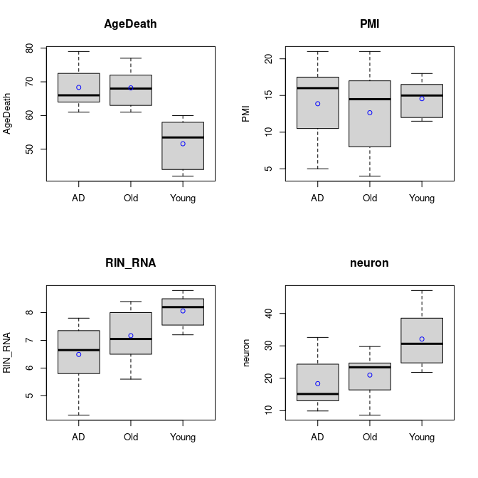

```r
> par(mfrow = c(2, 2))
> for (i in 1:dim(metadata.copy)[2]) {
+     if (class(metadata.copy[, i]) != "factor") {
+         boxplot(metadata.copy[, i] ~ metadata.copy$Group, main = colnames(metadata.copy)[i],
+             ylab = colnames(metadata.copy)[i], xlab = "")
+         means <- tapply(metadata.copy[, i], metadata.copy$Group,
+             mean)
+         points(means, col = "blue")
+
+     }
+ }
```

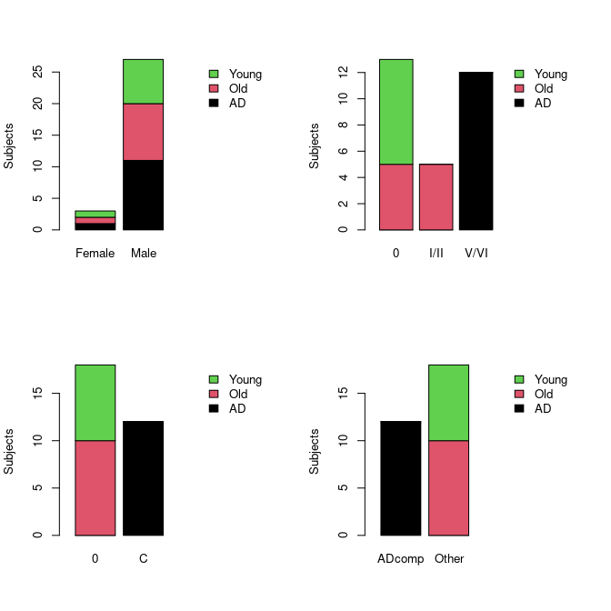

```r
> x <- metadata.copy[, c(2, 5, 6, 9)]
> y <- apply(x, 2, function(column) table(metadata.copy$Group,
+     column))
> par(mfrow = c(2, 2))
> for (i in 1:length(y)) {
+     y.t <- y[[i]]
+     barplot(y.t, xlim = c(0, ncol(y.t) + 3), col = 1:3, ylab = "Subjects",
+         legend.text = T, args.legend = list(x = ncol(y.t) + 3,
+             y = max(colSums(y.t)), bty = "n"))
+
+
+ }
```

#### 1.2.1.1 (EXTRA IF NEEDED) Analysis betwwen groups and other features

```r
> with(metadata.copy, bartlett.test(AgeDeath ~ Group))
```

```
    Bartlett test of homogeneity of variances

data:  AgeDeath by Group
Bartlett's K-squared = 1.0284, df = 2, p-value = 0.598
```

```r
> with(metadata.copy, bartlett.test(PMI ~ Group))
```

```
    Bartlett test of homogeneity of variances

data:  PMI by Group
Bartlett's K-squared = 4.3814, df = 2, p-value = 0.1118
```

```r
> with(metadata.copy, bartlett.test(RIN_RNA ~ Group))
```

```
    Bartlett test of homogeneity of variances

data:  RIN_RNA by Group
Bartlett's K-squared = 2.6403, df = 2, p-value = 0.2671
```

```r
> with(metadata.copy, bartlett.test(neuron ~ Group))
```

```
    Bartlett test of homogeneity of variances

data:  neuron by Group
Bartlett's K-squared = 0.99593, df = 2, p-value = 0.6078
```

```r
> with(metadata.copy, shapiro.test(AgeDeath))
```

```
    Shapiro-Wilk normality test

data:  AgeDeath
W = 0.94477, p-value = 0.1223
```

```r
> with(metadata.copy, shapiro.test(PMI))
```

```
    Shapiro-Wilk normality test

data:  PMI
W = 0.93164, p-value = 0.05429
```

```r
> with(metadata.copy, shapiro.test(RIN_RNA))
```

```
    Shapiro-Wilk normality test

data:  RIN_RNA
W = 0.95786, p-value = 0.2729
```

```r
> with(metadata.copy, shapiro.test(neuron))
```

```
    Shapiro-Wilk normality test

data:  neuron
W = 0.95071, p-value = 0.1766
```

```r
> summary(with(metadata.copy, aov(AgeDeath ~ Group)))
```

```
            Df Sum Sq Mean Sq F value   Pr(>F)
Group        2   1626   813.0   21.56 2.54e-06 ***
Residuals   27   1018    37.7
---
Signif. codes:  0 '***' 0.001 '**' 0.01 '*' 0.05 '.' 0.1 ' ' 1
```

```r
> pairwise.t.test(metadata.copy$AgeDeath, metadata.copy$Group,
+     method = "bonferroni")
```

```
    Pairwise comparisons using t tests with pooled SD

data:  metadata.copy$AgeDeath and metadata.copy$Group

      AD      Old
Old   0.96    -
Young 7.0e-06 9.6e-06

P value adjustment method: holm
```

Performing anova over the controls and AD subjects, we can observe that there are statistican significance between old , young, AD, young subjects. But there is not statistical significance between Old and AD subjects.

```r
> summary(with(metadata.copy, aov(PMI ~ Group)))
```

```
            Df Sum Sq Mean Sq F value Pr(>F)
Group        2   17.3   8.634   0.368  0.695
Residuals   27  632.8  23.437
```

Anova indicating that there is not significance evidence between the post mortem interval between subjects.

```r
> summary(with(metadata.copy, aov(RIN_RNA ~ Group)))
```

```
            Df Sum Sq Mean Sq F value  Pr(>F)
Group        2  11.86   5.930   6.996 0.00357 **
Residuals   27  22.89   0.848
---
Signif. codes:  0 '***' 0.001 '**' 0.01 '*' 0.05 '.' 0.1 ' ' 1
```

```r
> pairwise.t.test(metadata.copy$RIN_RNA, metadata.copy$Group, method = "bonferroni")
```

```
    Pairwise comparisons using t tests with pooled SD

data:  metadata.copy$RIN_RNA and metadata.copy$Group

      AD     Old
Old   0.1017 -
Young 0.0026 0.1017

P value adjustment method: holm
```

The integrity numbers of RNA shows a statsitical evidence between AD and Young subjects. But there is no difference between old and young controls.

```r
> summary(with(metadata.copy, aov(neuron ~ Group)))
```

```
            Df Sum Sq Mean Sq F value  Pr(>F)
Group        2  963.5   481.7   8.731 0.00119 **
Residuals   27 1489.7    55.2
---
Signif. codes:  0 '***' 0.001 '**' 0.01 '*' 0.05 '.' 0.1 ' ' 1
```

```r
> pairwise.t.test(metadata.copy$neuron, metadata.copy$Group, method = "bonferroni")
```

```
    Pairwise comparisons using t tests with pooled SD

data:  metadata.copy$neuron and metadata.copy$Group

      AD     Old
Old   0.4091 -
Young 0.0011 0.0079

P value adjustment method: holm
```

# 2 RNA-seq exploratory analysis

## 2.1 Loading the superseries and RNA-seq subseries

```r
> # gse.superserie<-getGEO('GSE153875',destdir =
> # 'data/superserie',GSEMatrix = T)
> # gse.GSE130746<-getGEO('GSE130746',destdir =
> # 'ADdata/subseries/gse130746_chip_seq/',GSEMatrix = T)
> # #chip-seq
> gse.GSE153873 <- getGEO("GSE153873", destdir = "data/rnaseqData/",
+     GSEMatrix = T)  # RNA-seq
```

```
Found 1 file(s)
```

```
GSE153873_series_matrix.txt.gz
```

```
Using locally cached version: data/rnaseqData//GSE153873_series_matrix.txt.gz
```

```
Using locally cached version of GPL18573 found here:
data/rnaseqData//GPL18573.soft
```

```r
> counts <- read.csv("./data/rnaseqData/GSE153873_summary_count.star.txt",
+     header = T, sep = "\t", row.names = "refGene")
```

### 2.1.1 INVESTIGATION ABOUT THE UNKOWN FEATURE

First let’s investigate which T and A refer, and how they possible lines to metadata. Furthermore lets contrusct this data frame as a “targets” in which will go the pheno data.

```r
> title <- gse.GSE153873$GSE153873_series_matrix.txt.gz$title
> title.temp <- matrix(strsplit2(title, "-"), ncol = 3)
> title.temp.df <- as.data.frame(title.temp)
> colnames(title.temp.df) <- c("ID", "dontknow", "Group")
>
> title.temp.df$shortname <- paste(title.temp.df$Group, title.temp.df$dontknow,
+     title.temp.df$ID, sep = "_")
> title.temp.df$ID <- as.numeric(title.temp.df$ID)
> title.temp.df.ordered <- title.temp.df[order(title.temp.df$ID),
+     ]
> title.temp.df.ordered$dontknowID <- as.numeric(rownames(title.temp.df.ordered))
> w <- which(title.temp.df.ordered$dontknow %in% title.temp.df.ordered$dontknow[grep("A",
+     title.temp.df.ordered$dontknow)])
> title.temp.df.ordered$dontknowLetter <- numeric(length(nrow(title.temp)))
> title.temp.df.ordered$dontknowLetter[w] <- "A"
> title.temp.df.ordered$dontknowLetter[-w] <- "T"
> targets.temp <- cbind(title.temp.df.ordered, metadata.copy)
> targets.temp2 <- targets.temp[, -7]
> levels(targets.temp2$Gender) <- c("F", "M")
> targets.temp2$shortname <- paste(targets.temp2$Group, targets.temp2$dontknow,
+     targets.temp2$Gender, targets.temp2$Braak, targets.temp2$ID,
+     sep = "_")
> targets <- targets.temp2
```

```r
> write.csv(targets, file = "./results/targets.csv", sep = ",")
> coldata <- targets
> for (j in 1:ncol(targets)) {
+
+     if (class(targets[, j]) == "character") {
+         coldata[, j] <- as.factor(coldata[, j])
+     }
+ }
>
> col.namez <- strsplit2(colnames(counts), split = "[.]")
> col.namez[, 1] <- gsub("X", "", col.namez[, 1])
> col.namez.df <- as.data.frame(col.namez)
> colnames(col.namez.df) <- c("ID", "dontknow", "Group")
> col.namez.df$ID <- as.numeric(col.namez.df$ID)
> counts.order <- counts[, order(col.namez.df$ID)]
> col.namez.df$shortName <- paste(col.namez.df$Group, col.namez.df$dontknow,
+     col.namez.df$ID, sep = "_")
> col.namez.df$shortName.ordered <- col.namez.df$shortName[order(col.namez.df$ID)]
> counts.order <- counts[, order(col.namez.df$ID)]
> colnames(counts.order) <- col.namez.df$shortName.ordered
> colnames(counts.order) <- targets$shortname
```

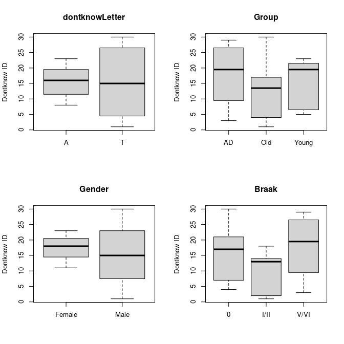

[figure not shown]

```r
> par(mfrow = c(2, 2))
> for (i in 1:dim(targets)[2]) {
+     if (class(targets[, i]) == "factor") {
+         if (colnames(targets)[i] != "dontknow") {
+             boxplot(targets$dontknowID ~ targets[, i], main = colnames(targets)[i],
+                 ylab = "Dontknow ID", xlab = "")
+             # means<-tapply(targets[,i], targets[,i], mean)
+             # points(means,col='blue')
+
+         }
+     }
+ }
```

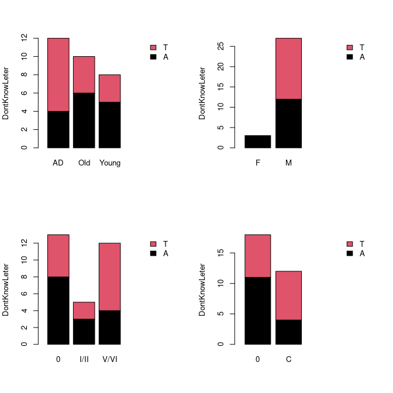

```r
> grupo <- table(targets$dontknowLetter, targets$Group)
> genero <- table(targets$dontknowLetter, targets$Gender)
> braak <- table(targets$dontknowLetter, targets$Braak)
> cerad <- table(targets$dontknowLetter, targets$Cerad)
> y <- list(grupo = grupo, genero = genero, braak = braak, cerad = cerad)
> par(mfrow = c(2, 2))
> for (i in 1:length(y)) {
+     y.t <- y[[i]]
+     barplot(y.t, xlim = c(0, ncol(y.t) + 3), col = 1:3, ylab = "DontKnowLeter",
+         legend.text = T, args.legend = list(x = ncol(y.t) + 3,
+             y = max(colSums(y.t)), bty = "n"))
+
+
+ }
```

## RNA-seq data exploration

```r
> head(counts.order)
```

```
        Young_12A_M_0_2 Young_17T_M_0_3 Young_13A_M_0_4 Young_18T_M_0_5
SGIP1              2602             859            3115            1164
NECAP2              409             617             196             585
AZIN2               611             787             323             751
AGBL4               328              36             335              89
CLIC4              2493            4806            1332            5968
SLC45A1             551             139             441             204
        Young_14A_M_0_6 Young_19T_M_0_7 Young_15A_M_0_8 Young_16A_F_0_9
SGIP1              2953            1402            1541            1614
NECAP2              220             372             424             387
AZIN2               396             577             394             424
AGBL4               431             184              38             231
CLIC4               729            1392            8812             689
SLC45A1             506             278             221             409
        Old_8A_M_I/II_10 Old_10T_M_0_11 Old_6A_M_0_12 Old_11T_M_I/II_13
SGIP1               2756           1174          2238              1405
NECAP2               217            350           356               460
AZIN2                427            575           421               306
AGBL4                327            156           268               200
CLIC4                719            665          1526              1443
SLC45A1              474            350           253               329
        Old_7A_M_I/II_14 Old_13T_M_I/II_15 Old_14T_M_0_16 Old_9A_M_0_17
SGIP1               1075              1169           2408          2413
NECAP2               344               334            347           470
AZIN2                296               385            507           394
AGBL4                200               173            323           282
CLIC4               1269               639            792          4716
SLC45A1              195               298            636           349
        Old_10A_M_0_18 Old_11A_F_I/II_19 AD_1T_M_V/VI_20 AD_1A_M_V/VI_21
SGIP1             1748              1322            1405            1441
NECAP2             403               338             295             343
AZIN2              360               264             356             238
AGBL4              202               213             191             229
CLIC4             1361               819             876            1117
SLC45A1            269               231             291             193
        AD_2T_M_V/VI_22 AD_2A_M_V/VI_23 AD_3T_M_V/VI_24 AD_5T_M_V/VI_25
SGIP1              1325            1003             795             833
NECAP2              491             374             426             552
AZIN2               440             209             179             567
AGBL4               124             129              46              45
CLIC4              3674            1247             936            2534
SLC45A1             224             152             156             138
        AD_3A_M_V/VI_26 AD_5A_F_V/VI_27 AD_8T_M_V/VI_28 AD_6T_M_V/VI_29
SGIP1              1265             987            1004            1284
NECAP2              315             355             474             328
AZIN2               241             211             319             292
AGBL4               154             102             108             123
CLIC4               929            1151            1406             856
SLC45A1             178             142             178             222
        AD_9T_M_V/VI_30 AD_7T_M_V/VI_31
SGIP1              1593             919
NECAP2              344             353
AZIN2               348             301
AGBL4               247             155
CLIC4              1255             646
SLC45A1             272             251
```

As a rule of thumb, genes are dropped if they can’t possibly be expressed in all the samples for any of the conditions. Users can set their own definition of genes being expressed. Usually a gene is required to have a count of 5-10 in a library to be considered expressed in that library. Users should also filter with count-per-million (CPM) rather than filtering on the counts directly, as the latter does not account for differences in library sizes between samples

First we create an structured list.

```r
> dge <- DGEList(counts = counts.order, group = targets$Group,
+     genes = rownames(counts.order))
```

```r
> dge$samples
```

```
                  group lib.size norm.factors
Young_12A_M_0_2   Young 19529531            1
Young_17T_M_0_3   Young 15240896            1
Young_13A_M_0_4   Young 18450134            1
Young_18T_M_0_5   Young 15687974            1
Young_14A_M_0_6   Young 15907240            1
Young_19T_M_0_7   Young 13792025            1
Young_15A_M_0_8   Young 16655001            1
Young_16A_F_0_9   Young 14652506            1
Old_8A_M_I/II_10    Old 15701441            1
Old_10T_M_0_11      Old 14082186            1
Old_6A_M_0_12       Old 14829927            1
Old_11T_M_I/II_13   Old 13891615            1
Old_7A_M_I/II_14    Old 12044572            1
Old_13T_M_I/II_15   Old 12711611            1
Old_14T_M_0_16      Old 17128505            1
Old_9A_M_0_17       Old 17951761            1
Old_10A_M_0_18      Old 14470576            1
Old_11A_F_I/II_19   Old 11668776            1
AD_1T_M_V/VI_20      AD 14008871            1
AD_1A_M_V/VI_21      AD 13219351            1
AD_2T_M_V/VI_22      AD 14721591            1
AD_2A_M_V/VI_23      AD 11598493            1
AD_3T_M_V/VI_24      AD 10789188            1
AD_5T_M_V/VI_25      AD 13182589            1
AD_3A_M_V/VI_26      AD 13298927            1
AD_5A_F_V/VI_27      AD 12119314            1
AD_8T_M_V/VI_28      AD 12727324            1
AD_6T_M_V/VI_29      AD 13192892            1
AD_9T_M_V/VI_30      AD 13499411            1
AD_7T_M_V/VI_31      AD 12772514            1
```

### 2.1.2 Filter

We filter out lowly expressed genes:

The `filterByExpr` function keeps rows that have worthwhile counts in a minimum of samples, 8 samples in our case. The function access the `group` factor contained in `dge` in order to compute the miimum group size, but the filtering is performed independently of which sample belongs to which group so that no bias is introduced. It is recommended to recalculate the library sizes of the `DGEList` object after the filtering, although the downstream analysis is robust to whether this is done or not.

```r
> keep <- filterByExpr(dge)
> dge_filt <- dge[keep, , keep.lib.sizes = F]
> dge_filt$samples
```

```
                  group lib.size norm.factors
Young_12A_M_0_2   Young 19516396            1
Young_17T_M_0_3   Young 15227264            1
Young_13A_M_0_4   Young 18438628            1
Young_18T_M_0_5   Young 15674477            1
Young_14A_M_0_6   Young 15894046            1
Young_19T_M_0_7   Young 13778746            1
Young_15A_M_0_8   Young 16642998            1
Young_16A_F_0_9   Young 14628340            1
Old_8A_M_I/II_10    Old 15688049            1
Old_10T_M_0_11      Old 14054728            1
Old_6A_M_0_12       Old 14817402            1
Old_11T_M_I/II_13   Old 13875539            1
Old_7A_M_I/II_14    Old 12030931            1
Old_13T_M_I/II_15   Old 12697813            1
Old_14T_M_0_16      Old 17112508            1
Old_9A_M_0_17       Old 17938281            1
Old_10A_M_0_18      Old 14457838            1
Old_11A_F_I/II_19   Old 11642670            1
AD_1T_M_V/VI_20      AD 13995963            1
AD_1A_M_V/VI_21      AD 13204906            1
AD_2T_M_V/VI_22      AD 14707635            1
AD_2A_M_V/VI_23      AD 11585655            1
AD_3T_M_V/VI_24      AD 10771550            1
AD_5T_M_V/VI_25      AD 13169966            1
AD_3A_M_V/VI_26      AD 13286924            1
AD_5A_F_V/VI_27      AD 12098333            1
AD_8T_M_V/VI_28      AD 12711556            1
AD_6T_M_V/VI_29      AD 13181228            1
AD_9T_M_V/VI_30      AD 13484859            1
AD_7T_M_V/VI_31      AD 12758282            1
```

### 2.1.3 Normalization TMM

```r
> dge_norm <- calcNormFactors(dge_filt)
```

```r
> ratio <- max(dge_norm$samples$lib.size)/min(dge_norm$samples$lib.size)
> ratio
```

```
[1] 1.811847
```

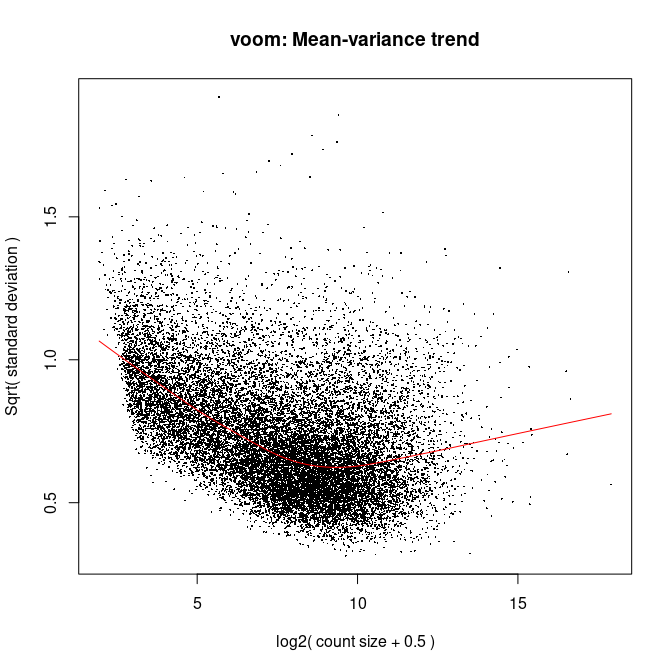

```r
> v <- voom(dge_norm, plot = T)
```

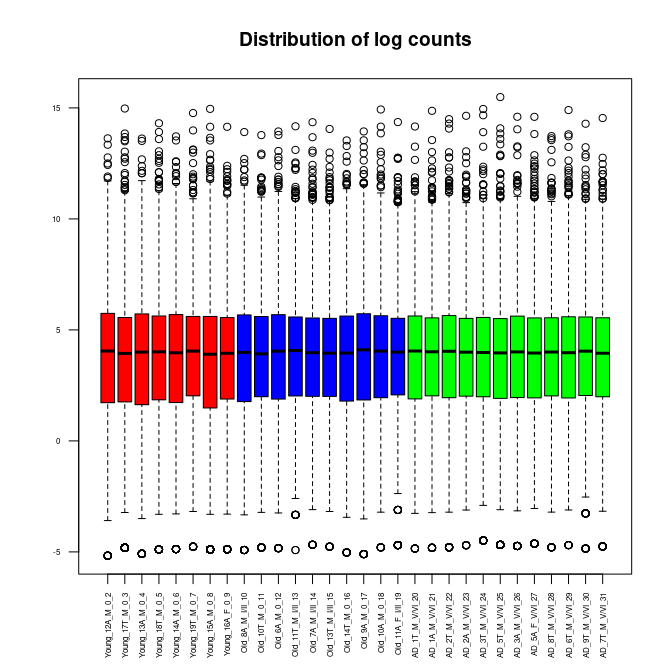

```r
> boxplot(v$E, cex.axis = 0.5, las = 2, which = "all", col = c(rep("red",
+     8), rep("blue", 10), rep("green", 12)), main = "Distribution of log counts",
+     names = rownames(v$targets))
```

### 2.1.4 PCA

```r
> plotPCA3 <- function(datos, labels, factor, title, scale, center,
+     colores, size = 1.5, glineas = 0.25) {
+     data <- prcomp(t(datos), scale = scale, center = center)
+     # plot adjustments
+     dataDf <- data.frame(data$x)
+     Group <- factor
+     loads <- round(data$sdev^2/sum(data$sdev^2) * 100, 1)
+     # main plot
+     p1 <- ggplot(dataDf, aes(x = PC1, y = PC2)) + theme_classic() +
+         geom_hline(yintercept = 0, color = "gray70") + geom_vline(xintercept = 0,
+         color = "gray70") + geom_point(aes(color = Group), alpha = 0.55,
+         size = 3) + coord_cartesian(xlim = c(min(data$x[, 1]) -
+         5, max(data$x[, 1]) + 5)) + scale_fill_discrete(name = "Group")
+     # avoiding labels superposition
+     grafico <- p1 + geom_text_repel(aes(y = PC2 + 0.25, label = labels),
+         segment.size = 0.25, size = size) + labs(x = c(paste("PC1",
+         loads[1], "%")), y = c(paste("PC2", loads[2], "%"))) +
+         ggtitle(paste("Principal Component Analysis for: ", title,
+             sep = " ")) + theme(plot.title = element_text(hjust = 0.5)) +
+         scale_color_manual(values = colores)
+     return(list(loads = loads, grafico = grafico))
+ }
```

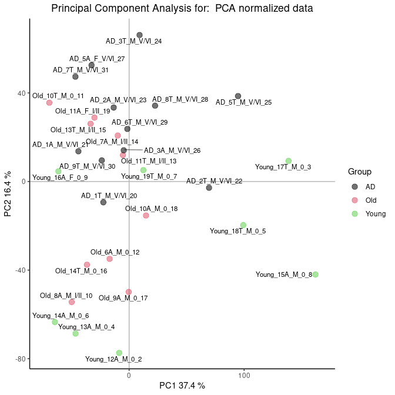

```r
> loads <- plotPCA3(v$E, labels = rownames(v$targets), factor = v$targets$group,
+     title = "PCA normalized data", scale = F, center = T, size = 3,
+     colores = 1:7)
> loads$grafico
```

```r
> adj_counts <- ComBat_seq(dge_norm$counts, batch = targets$dontknowLetter,
+     group = targets$Group)
```

```
Found 2 batches
Using full model in ComBat-seq.
Adjusting for 2 covariate(s) or covariate level(s)
Estimating dispersions
Fitting the GLM model
Shrinkage off - using GLM estimates for parameters
Adjusting the data
```

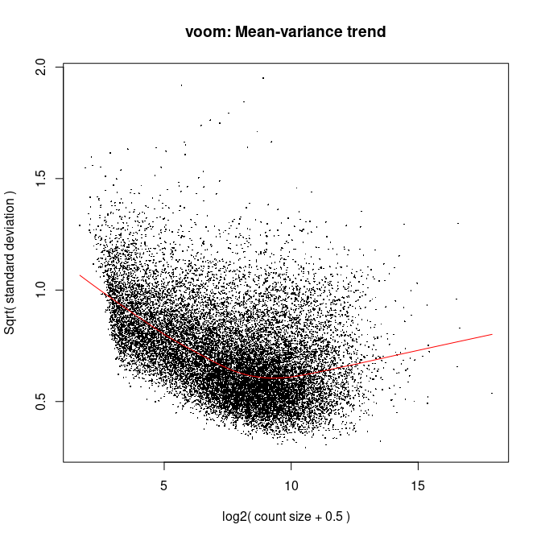

```r
> dge_norm.copy <- dge_norm
> dge_norm.copy$counts <- adj_counts
> myvoom <- voom(dge_norm.copy, plot = T)
```

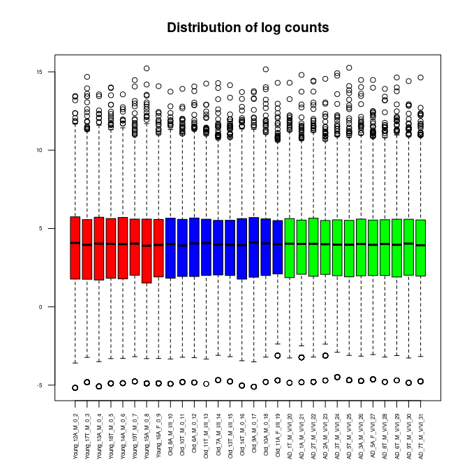

```r
> boxplot(myvoom$E, cex.axis = 0.5, las = 2, which = "all", col = c(rep("red",
+     8), rep("blue", 10), rep("green", 12)), main = "Distribution of log counts",
+     names = rownames(myvoom$targets))
```

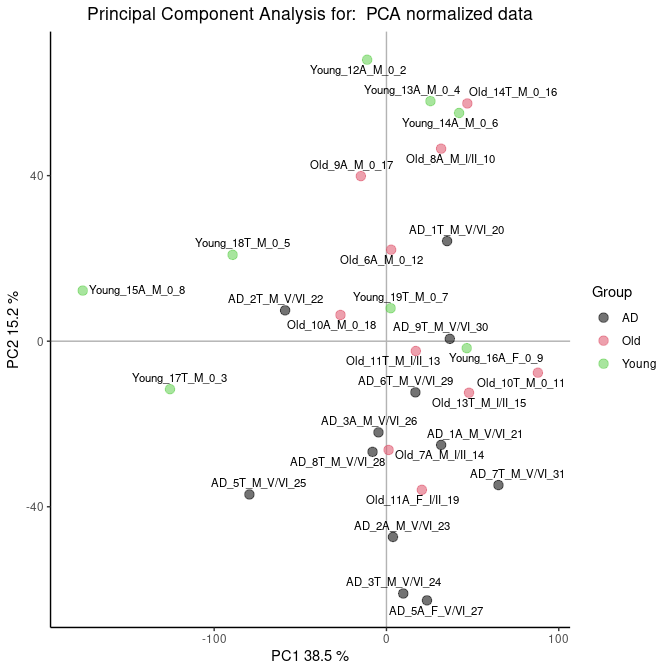

```r
> loads <- plotPCA3(myvoom$E, labels = rownames(myvoom$targets),
+     factor = myvoom$targets$group, title = "PCA normalized data",
+     scale = F, center = T, size = 3, colores = 1:7)
> loads$grafico
```